# PEC 2 - Regresión, modelos y métodos

Candela Sánchez

2026-01-13

## Ejercicio 1 (35 pt.)

Los datos que utilizaremos son de McDonald y Schwing (1973) y contienen 15 variables independientes y una medida de la mortalidad en 60 áreas metropolitanas de los Estados Unidos entre 1959 y 1961.

La base de datos está en el *data.frame* **mcdonald** del paquete **bestglm**. En esta base de datos la variable respuesta es **MORT**. Las otras son todas variables regresoras.

El objetivo principal de este ejercicio es mostrar qué variables son importantes en la predicción de la mortalidad. Sin embargo, el conjunto de variables regresoras presenta algunos problemas y deberemos tratarlos adecuadamente. De momento **no dividiremos** la base de datos en los grupos habituales de entrenamiento y contraste.

```r
# Primero vamos a cargar el paquete y los datos que vamos a utilizar
library(bestglm)
data(mcdonald)
# Observamos la estructura de los datos descargados
str(mcdonald)
```

```
## 'data.frame':    60 obs. of  16 variables:
##  $ PREC : num  36 35 44 47 43 53 43 45 36 36 ...
##  $ JANT : num  27 23 29 45 35 45 30 30 24 27 ...
##  $ JULT : num  71 72 74 79 77 80 74 73 70 72 ...
##  $ OVR65: num  8.1 11.1 10.4 6.5 7.6 7.7 10.9 9.3 9 9.5 ...
##  $ POPN : num  3.34 3.14 3.21 3.41 3.44 3.45 3.23 3.29 3.31 3.36 ...
##  $ EDUC : num  11.4 11 9.8 11.1 9.6 10.2 12.1 10.6 10.5 10.7 ...
##  $ HOUS : num  81.5 78.8 81.6 77.5 84.6 66.8 83.9 86 83.2 79.3 ...
##  $ DENS : num  3243 4281 4260 3125 6441 ...
##  $ NONW : num  8.8 3.5 0.8 27.1 24.4 38.5 3.5 5.3 8.1 6.7 ...
##  $ WWDRK: num  42.6 50.7 39.4 50.2 43.7 43.1 49.2 40.4 42.5 41 ...
##  $ POOR : num  11.7 14.4 12.4 20.6 14.3 25.5 11.3 10.5 12.6 13.2 ...
##  $ HC   : num  21 8 6 18 43 30 21 6 18 12 ...
##  $ NOX  : num  15 10 6 8 38 32 32 4 12 7 ...
##  $ SOx  : num  59 39 33 24 206 72 62 4 37 20 ...
##  $ HUMID: num  59 57 54 56 55 54 56 56 61 59 ...
##  $ MORT : num  922 998 962 982 1071 ...
```

### a. Empezaremos por realizar un rápido análisis de los residuos del modelo lineal ordinario y destacaremos los puntos más conflictivos.

### Eliminaremos del estudio el punto más influyente.

```r
# Realizamos el modelo lineal
modelo <- lm(MORT ~., data = mcdonald)
summary(modelo)
```

```
##
## Call:
## lm(formula = MORT ~ ., data = mcdonald)
##
## Residuals:
##     Min      1Q  Median      3Q     Max
## -68.066 -18.017   0.912  19.224  86.961
##
## Coefficients:
##               Estimate Std. Error t value Pr(>|t|)
## (Intercept)  1.764e+03  4.373e+02   4.034 0.000215 ***
## PREC         1.905e+00  9.237e-01   2.063 0.045071 *
## JANT        -1.938e+00  1.108e+00  -1.748 0.087413 .
## JULT        -3.100e+00  1.902e+00  -1.630 0.110159
## OVR65       -9.065e+00  8.486e+00  -1.068 0.291230
## POPN        -1.068e+02  6.978e+01  -1.531 0.132952
## EDUC        -1.716e+01  1.186e+01  -1.447 0.155085
## HOUS        -6.511e-01  1.768e+00  -0.368 0.714393
## DENS         3.600e-03  4.027e-03   0.894 0.376147
## NONW         4.460e+00  1.327e+00   3.360 0.001618 **
## WWDRK       -1.871e-01  1.662e+00  -0.113 0.910883
## POOR        -1.676e-01  3.227e+00  -0.052 0.958807
## HC          -6.721e-01  4.910e-01  -1.369 0.177985
## NOX          1.340e+00  1.006e+00   1.333 0.189506
## SOx          8.625e-02  1.475e-01   0.585 0.561745
## HUMID        1.068e-01  1.169e+00   0.091 0.927644
## ---
## Signif. codes:  0 '***' 0.001 '**' 0.01 '*' 0.05 '.' 0.1 ' ' 1
##
## Residual standard error: 34.93 on 44 degrees of freedom
## Multiple R-squared:  0.7649, Adjusted R-squared:  0.6847
## F-statistic: 9.542 on 15 and 44 DF,  p-value: 2.193e-09
```

Podemos observar que en los residuos del modelo hay observaiones muy alejadas, por lo que podrían ser conflictivas, ya que el residuo mínimo es -68 y el máximo es aproximadamente 87.

A continuación, vamos a realizar un gráfico de residuos para observar si hay puntos conflictivos.

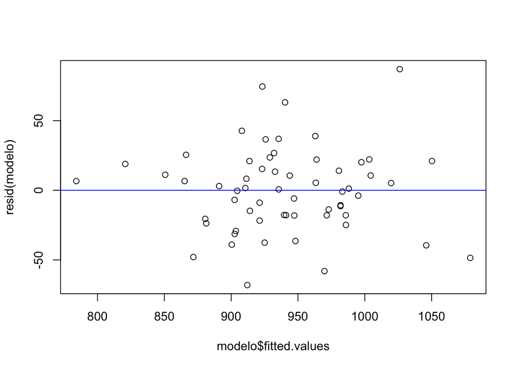

```r
# Gráfico de residuos frente a los valores ajustados
plot(modelo$fitted.values, resid(modelo))
abline(h=0, col="blue")
```

Se puede observar en el gráfico que hay varios puntos alejados de 0 por lo que hay algunos puntos influyentes.

Como debemos eliminar el punto más influyente, primero vamos a identificarlo mediante la distancia de Cook, en la cual, el punto más influyente sera el que mayor distancia de Cook tenga.

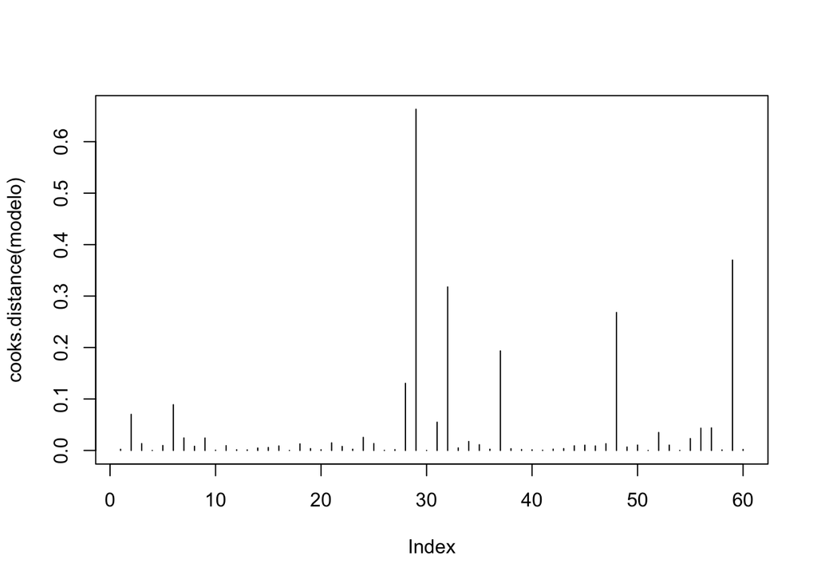

```r
# Distancia de Cook
plot(cooks.distance(modelo), type = "h")
```

```r
# Hallamos cual es el punto mas influyente para poder eliminarlo
punto_influyente <- which.max(cooks.distance(modelo))
mcdonald_reducida <- mcdonald[-punto_influyente,]
# Observamos la estrucutra de los nuevos datos
str(mcdonald_reducida)
```

```
## 'data.frame':    59 obs. of  16 variables:
##  $ PREC : num  36 35 44 47 43 53 43 45 36 36 ...
##  $ JANT : num  27 23 29 45 35 45 30 30 24 27 ...
##  $ JULT : num  71 72 74 79 77 80 74 73 70 72 ...
##  $ OVR65: num  8.1 11.1 10.4 6.5 7.6 7.7 10.9 9.3 9 9.5 ...
##  $ POPN : num  3.34 3.14 3.21 3.41 3.44 3.45 3.23 3.29 3.31 3.36 ...
##  $ EDUC : num  11.4 11 9.8 11.1 9.6 10.2 12.1 10.6 10.5 10.7 ...
##  $ HOUS : num  81.5 78.8 81.6 77.5 84.6 66.8 83.9 86 83.2 79.3 ...
##  $ DENS : num  3243 4281 4260 3125 6441 ...
##  $ NONW : num  8.8 3.5 0.8 27.1 24.4 38.5 3.5 5.3 8.1 6.7 ...
##  $ WWDRK: num  42.6 50.7 39.4 50.2 43.7 43.1 49.2 40.4 42.5 41 ...
##  $ POOR : num  11.7 14.4 12.4 20.6 14.3 25.5 11.3 10.5 12.6 13.2 ...
##  $ HC   : num  21 8 6 18 43 30 21 6 18 12 ...
##  $ NOX  : num  15 10 6 8 38 32 32 4 12 7 ...
##  $ SOx  : num  59 39 33 24 206 72 62 4 37 20 ...
##  $ HUMID: num  59 57 54 56 55 54 56 56 61 59 ...
##  $ MORT : num  922 998 962 982 1071 ...
```

```r
# Ajustamos el modelo de nuevo
modelo_red <- lm(MORT~., data = mcdonald_reducida)
summary(modelo_red)
```

```
##
## Call:
## lm(formula = MORT ~ ., data = mcdonald_reducida)
##
## Residuals:
##     Min      1Q  Median      3Q     Max
## -63.812 -20.244   0.858  18.654  80.733
##
## Coefficients:
##               Estimate Std. Error t value Pr(>|t|)
## (Intercept)  1.875e+03  4.496e+02   4.171 0.000144 ***
## PREC         1.517e+00  9.945e-01   1.526 0.134389
## JANT        -1.774e+00  1.118e+00  -1.586 0.119986
## JULT        -3.666e+00  1.975e+00  -1.856 0.070283 .
## OVR65       -1.016e+01  8.541e+00  -1.189 0.240830
## POPN        -1.282e+02  7.264e+01  -1.765 0.084668 .
## EDUC        -2.037e+01  1.224e+01  -1.665 0.103271
## HOUS        -4.134e-01  1.780e+00  -0.232 0.817473
## DENS         3.435e-03  4.026e-03   0.853 0.398276
## NONW         4.848e+00  1.377e+00   3.521 0.001031 **
## WWDRK        7.545e-02  1.679e+00   0.045 0.964360
## POOR        -4.518e-01  3.235e+00  -0.140 0.889601
## HC          -1.100e+00  6.387e-01  -1.722 0.092207 .
## NOX          1.818e+00  1.103e+00   1.647 0.106783
## SOx          5.695e-02  1.500e-01   0.380 0.706082
## HUMID        6.030e-01  1.261e+00   0.478 0.634905
## ---
## Signif. codes:  0 '***' 0.001 '**' 0.01 '*' 0.05 '.' 0.1 ' ' 1
##
## Residual standard error: 34.89 on 43 degrees of freedom
## Multiple R-squared:  0.7642, Adjusted R-squared:  0.682
## F-statistic: 9.292 on 15 and 43 DF,  p-value: 4.207e-09
```

Se puede observar que el punto más influente ha sido eliminado porque en vez de 60 observaciones tenemos 59.

### A continuación estudiaremos la posible multicolinealidad del conjunto de variables regresoras.

#### i) Calcular y dibujar las correlaciones dos a dos de las variables regresoras y comentar el resultado.

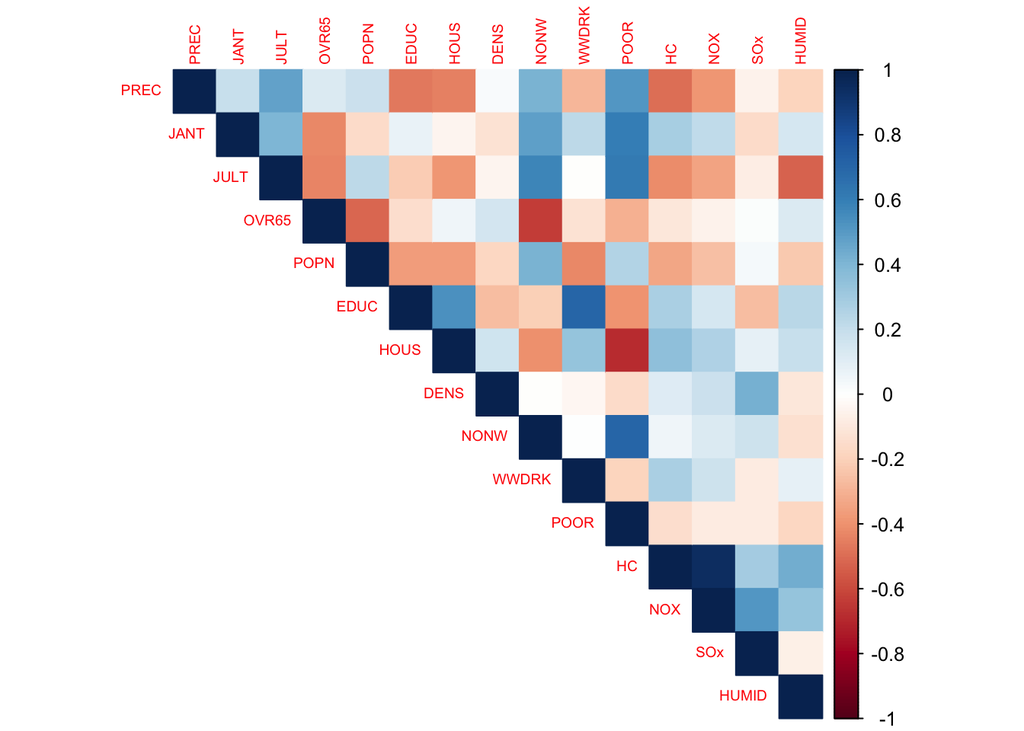

```r
# Primero debemos seleccionar unicamente las variables regresoras por lo que debemos descartar la variable respuesta MORT
var_regresoras<- mcdonald_reducida[, colnames(mcdonald_reducida)!="MORT"]
# Una vez descartada la variable MORT calculamos las correlacions
correlacion <- cor(var_regresoras)
# Dibujamos las correlaciones
library(corrplot)
corrplot(correlacion, method = "color", type = "upper", tl.cex=0.6)
```

Se puede observar en el gráfico de correlaciones que no todas las variables son independientes entre sí. Muestra que hay varias variables con correlaciones fuertes como es el caso de HC con NOX, EDUC con WWWDRK y NONW con POOR, lo que sugiere que hay multicolinealidad debido a que varias variales continen información parecida.

#### ii) Calcular el número de condición de la matriz de diseño del modelo lineal ordinario.

```r
# Calculamos la matriz de diseño
matriz_diseño<- model.matrix(modelo_red)[,-1] # Quitamos la primera columna que es el intercepto
# Calculamos el numero de condicione de la matriz
kappa(matriz_diseño)
```

```
## [1] 29107.91
```

El número de condición de la matriz diseño es 29107.91, lo que es un número bastante elevado que nos indica una presencia importante de multicolinealidad.

#### iii) Calcular los números de inflación de la varianza (VIFs) y destacar los más importantes.

```r
# Calculamos VIF
library(car) # Cargamos el paquete necesario para hallarlo
vif(modelo_red)
```

```
##      PREC      JANT      JULT     OVR65      POPN      EDUC      HOUS      DENS
##  4.204393  5.888631  4.148472  7.573763  4.349386  5.029372  3.812469  1.651659
##      NONW     WWDRK      POOR        HC       NOX       SOx     HUMID
##  7.286206  2.887846  8.741369 40.397254 37.352673  4.272585  2.070498
```

Los VIF muestran si existe multicolinealidad en el modelo. Como podemos observar en los resultados, las variables HC y NOX tienen un VIF muy alto ya que los valores son mayores de 10, lo que indica una multicolinealidad muy fuerte. Tambien, hay variables como JANT, OVR65, EDUC, NONW y POOR que presentan VIF altos indicando una colinealidad importante.

Estos resultados coinciden con los observados en el mapa de correlaciones dibujados anteriormente.

#### iv) ¿Tenemos un problema de multicolinealidad? ¿Cómo lo corregimos? (Solo propuestas sin cálculos)

Como se ha comentado en los apartados anteriores, hay un problema claro de multicolinealidad en el modelo. Se observan correlaciones altas entre las variables regresoras, un número de condición bastante elevado y valores altos de VIF, sobre todo en las variables HC y NOX.

Este problema podría corregirse eliminando las variables regresoras que estan altamente correlacionadas entre sí, utilizando métodos de regularización, como la regresión Ridge, que reduce este efecto, o mediante PCR que sustituye las variables originales por otras no correlacionadas y ayuda a encontrar modelos más simples y estables.

### b. En primer lugar realizaremos una selección de variables clásica por el método de eliminación hacia atrás o backward elimination con el estadístico F de Fisher.

```r
# Primero vamos a preparar los datos que necesitamos
modelo_completo = modelo_red
modelo_nulo <- lm(MORT~1, data=mcdonald_reducida) # Solo el intercepto
# Realizamos backward con estadistico F de Fisher usando el modelo completo
backward_fisher <- step(modelo_completo, direction = "backward", test="F")
```

```
## Start:  AIC=432.5
## MORT ~ PREC + JANT + JULT + OVR65 + POPN + EDUC + HOUS + DENS +
##     NONW + WWDRK + POOR + HC + NOX + SOx + HUMID
##
##         Df Sum of Sq   RSS    AIC F value   Pr(>F)
## - WWDRK  1       2.5 52351 430.50  0.0020 0.964360
## - POOR   1      23.7 52372 430.53  0.0195 0.889601
## - HOUS   1      65.6 52414 430.57  0.0539 0.817473
## - SOx    1     175.5 52524 430.70  0.1441 0.706082
## - HUMID  1     278.4 52627 430.81  0.2287 0.634905
## - DENS   1     886.2 53234 431.49  0.7279 0.398276
## - OVR65  1    1722.1 54070 432.41  1.4145 0.240830
## <none>               52348 432.50
## - PREC   1    2834.1 55182 433.61  2.3280 0.134389
## - JANT   1    3063.6 55412 433.86  2.5165 0.119986
## - NOX    1    3303.6 55652 434.11  2.7136 0.106783
## - EDUC   1    3373.1 55721 434.18  2.7708 0.103271
## - HC     1    3611.1 55959 434.44  2.9662 0.092207 .
## - POPN   1    3792.4 56141 434.63  3.1152 0.084668 .
## - JULT   1    4194.6 56543 435.05  3.4456 0.070283 .
## - NONW   1   15094.5 67443 445.45 12.3990 0.001031 **
## ---
## Signif. codes:  0 '***' 0.001 '**' 0.01 '*' 0.05 '.' 0.1 ' ' 1
##
## Step:  AIC=430.5
## MORT ~ PREC + JANT + JULT + OVR65 + POPN + EDUC + HOUS + DENS +
##     NONW + POOR + HC + NOX + SOx + HUMID
##
##         Df Sum of Sq   RSS    AIC F value    Pr(>F)
## - POOR   1      27.4 52378 428.53  0.0230 0.8801464
## - HOUS   1      76.6 52427 428.59  0.0644 0.8008851
## - SOx    1     201.1 52552 428.73  0.1691 0.6829491
## - HUMID  1     278.5 52629 428.82  0.2341 0.6309238
## - DENS   1     909.7 53260 429.52  0.7646 0.3866397
## - OVR65  1    1767.5 54118 430.46  1.4856 0.2294010
## <none>               52351 430.50
## - PREC   1    2839.1 55190 431.62  2.3862 0.1295730
## - JANT   1    3184.7 55535 431.99  2.6767 0.1089632
## - NOX    1    3531.7 55882 432.35  2.9683 0.0919321 .
## - HC     1    3793.2 56144 432.63  3.1882 0.0810670 .
```

[output cut: 91 more lines]

```
##     NOX
##
##         Df Sum of Sq   RSS    AIC F value    Pr(>F)
## <none>               54126 422.47
## - OVR65  1    3069.6 57196 423.73  2.7789  0.101896
## - PREC   1    3436.6 57563 424.10  3.1111  0.083994 .
## - POPN   1    7003.5 61130 427.65  6.3403  0.015120 *
## - JULT   1    7300.5 61427 427.94  6.6091  0.013234 *
## - JANT   1    8727.4 62853 429.29  7.9009  0.007084 **
## - HC     1    8895.0 63021 429.45  8.0526  0.006592 **
## - NOX    1   11617.3 65743 431.94 10.5171  0.002132 **
## - EDUC   1   12689.0 66815 432.90 11.4873  0.001391 **
## - NONW   1   26708.6 80835 444.13 24.1792 1.027e-05 ***
## ---
## Signif. codes:  0 '***' 0.001 '**' 0.01 '*' 0.05 '.' 0.1 ' ' 1
```

```r
# Resumen estadistido
summary(backward_fisher)
```

```
##
## Call:
## lm(formula = MORT ~ PREC + JANT + JULT + OVR65 + POPN + EDUC +
##     NONW + HC + NOX, data = mcdonald_reducida)
##
## Residuals:
##     Min      1Q  Median      3Q     Max
## -66.141 -24.521  -1.448  20.309  77.910
##
## Coefficients:
##              Estimate Std. Error t value Pr(>|t|)
## (Intercept) 2094.5241   366.1302   5.721 6.29e-07 ***
## PREC           1.5574     0.8830   1.764  0.08399 .
## JANT          -2.0403     0.7259  -2.811  0.00708 **
## JULT          -4.2754     1.6630  -2.571  0.01323 *
## OVR65        -12.0125     7.2061  -1.667  0.10190
## POPN        -158.6879    63.0217  -2.518  0.01512 *
## EDUC         -23.9727     7.0731  -3.389  0.00139 **
## NONW           4.9700     1.0107   4.917 1.03e-05 ***
## HC            -1.2348     0.4351  -2.838  0.00659 **
## NOX            2.1391     0.6596   3.243  0.00213 **
## ---
## Signif. codes:  0 '***' 0.001 '**' 0.01 '*' 0.05 '.' 0.1 ' ' 1
##
## Residual standard error: 33.24 on 49 degrees of freedom
## Multiple R-squared:  0.7562, Adjusted R-squared:  0.7115
## F-statistic: 16.89 on 9 and 49 DF,  p-value: 3.197e-12
```

### Repetiremos la selección backward con el estadístico AIC y compararemos los resultados.

```r
# Realizamos la seleccion backward con el estadistico AIC
backward_AIC <- step(modelo_completo, direction = "backward")
```

```
## Start:  AIC=432.5
## MORT ~ PREC + JANT + JULT + OVR65 + POPN + EDUC + HOUS + DENS +
##     NONW + WWDRK + POOR + HC + NOX + SOx + HUMID
##
##         Df Sum of Sq   RSS    AIC
## - WWDRK  1       2.5 52351 430.50
## - POOR   1      23.7 52372 430.53
## - HOUS   1      65.6 52414 430.57
## - SOx    1     175.5 52524 430.70
## - HUMID  1     278.4 52627 430.81
## - DENS   1     886.2 53234 431.49
## - OVR65  1    1722.1 54070 432.41
## <none>               52348 432.50
## - PREC   1    2834.1 55182 433.61
## - JANT   1    3063.6 55412 433.86
## - NOX    1    3303.6 55652 434.11
## - EDUC   1    3373.1 55721 434.18
## - HC     1    3611.1 55959 434.44
## - POPN   1    3792.4 56141 434.63
## - JULT   1    4194.6 56543 435.05
## - NONW   1   15094.5 67443 445.45
##
## Step:  AIC=430.5
## MORT ~ PREC + JANT + JULT + OVR65 + POPN + EDUC + HOUS + DENS +
##     NONW + POOR + HC + NOX + SOx + HUMID
##
##         Df Sum of Sq   RSS    AIC
## - POOR   1      27.4 52378 428.53
## - HOUS   1      76.6 52427 428.59
## - SOx    1     201.1 52552 428.73
## - HUMID  1     278.5 52629 428.82
## - DENS   1     909.7 53260 429.52
## - OVR65  1    1767.5 54118 430.46
## <none>               52351 430.50
## - PREC   1    2839.1 55190 431.62
## - JANT   1    3184.7 55535 431.99
## - NOX    1    3531.7 55882 432.35
## - HC     1    3793.2 56144 432.63
## - POPN   1    3812.3 56163 432.65
## - JULT   1    4207.0 56558 433.06
```

[output cut: 77 more lines]

```
## Step:  AIC=422.47
## MORT ~ PREC + JANT + JULT + OVR65 + POPN + EDUC + NONW + HC +
##     NOX
##
##         Df Sum of Sq   RSS    AIC
## <none>               54126 422.47
## - OVR65  1    3069.6 57196 423.73
## - PREC   1    3436.6 57563 424.10
## - POPN   1    7003.5 61130 427.65
## - JULT   1    7300.5 61427 427.94
## - JANT   1    8727.4 62853 429.29
## - HC     1    8895.0 63021 429.45
## - NOX    1   11617.3 65743 431.94
## - EDUC   1   12689.0 66815 432.90
## - NONW   1   26708.6 80835 444.13
```

```r
# Resumen estadistisco
summary(backward_AIC)
```

```
##
## Call:
## lm(formula = MORT ~ PREC + JANT + JULT + OVR65 + POPN + EDUC +
##     NONW + HC + NOX, data = mcdonald_reducida)
##
## Residuals:
##     Min      1Q  Median      3Q     Max
## -66.141 -24.521  -1.448  20.309  77.910
##
## Coefficients:
##              Estimate Std. Error t value Pr(>|t|)
## (Intercept) 2094.5241   366.1302   5.721 6.29e-07 ***
## PREC           1.5574     0.8830   1.764  0.08399 .
## JANT          -2.0403     0.7259  -2.811  0.00708 **
## JULT          -4.2754     1.6630  -2.571  0.01323 *
## OVR65        -12.0125     7.2061  -1.667  0.10190
## POPN        -158.6879    63.0217  -2.518  0.01512 *
## EDUC         -23.9727     7.0731  -3.389  0.00139 **
## NONW           4.9700     1.0107   4.917 1.03e-05 ***
## HC            -1.2348     0.4351  -2.838  0.00659 **
## NOX            2.1391     0.6596   3.243  0.00213 **
## ---
## Signif. codes:  0 '***' 0.001 '**' 0.01 '*' 0.05 '.' 0.1 ' ' 1
##
## Residual standard error: 33.24 on 49 degrees of freedom
## Multiple R-squared:  0.7562, Adjusted R-squared:  0.7115
## F-statistic: 16.89 on 9 and 49 DF,  p-value: 3.197e-12
```

```r
# Comparamos las variables que se han seleccionado por cada método
formula(backward_fisher)
```

```
## MORT ~ PREC + JANT + JULT + OVR65 + POPN + EDUC + NONW + HC +
##     NOX
```

```r
formula(backward_AIC)
```

```
## MORT ~ PREC + JANT + JULT + OVR65 + POPN + EDUC + NONW + HC +
##     NOX
```

En este caso ambos métodos seleccionan el mismo modelo final: MORT ~ PREC + JANT + JULT + OVR65 + POPN + EDUC + NONW + HC + NOX con un valor de AIC= 422.47. Esto significa que estas variables son las más importantes.

### Finalmente haremos la selección hacia adelante o forward selection con el estadístico AIC y compararemos resultados.

```r
# Realizamos el foward con el estadistico AIC, pero esta vez con el modelo nulo
forward_AIC<- step(modelo_nulo, scope=formula(modelo_completo), direction = "forward")
```

```
## Start:  AIC=487.75
## MORT ~ 1
##
##         Df Sum of Sq    RSS    AIC
## + NONW   1     92048 129989 458.16
## + EDUC   1     54713 167324 473.06
## + PREC   1     53026 169010 473.65
## + SOx    1     47849 174188 475.43
## + POOR   1     36621 185416 479.12
## + HOUS   1     36201 185836 479.25
## + POPN   1     24116 197921 482.97
## + DENS   1     17721 204316 484.84
## + WWDRK  1     16939 205098 485.07
## + JULT   1     14396 207641 485.80
## <none>               222037 487.75
## + OVR65  1      6501 215536 488.00
## + HUMID  1      4250 217787 488.61
## + NOX    1      2956 219081 488.96
## + HC     1      1023 221014 489.48
## + JANT   1        28 222009 489.74
##
## Step:  AIC=458.16
## MORT ~ NONW
##
##         Df Sum of Sq    RSS    AIC
## + EDUC   1   31088.9  98900 444.04
## + SOx    1   28663.4 101325 445.46
## + JANT   1   26198.8 103790 446.88
## + OVR65  1   21384.7 108604 449.56
## + DENS   1   17820.0 112169 451.46
## + WWDRK  1   16972.2 113017 451.91
## + PREC   1   12897.5 117091 454.00
## + HOUS   1    5261.9 124727 457.72
## + JULT   1    4432.1 125557 458.12
## <none>               129989 458.16
## + HC     1    2335.2 127654 459.09
## + POOR   1     972.3 129017 459.72
## + POPN   1     957.4 129032 459.73
## + HUMID  1     545.8 129443 459.91
## + NOX    1     257.8 129731 460.05
```

[output cut: 84 more lines]

```
## + POOR   1      0.28 60515 425.05
##
## Step:  AIC=422.85
## MORT ~ NONW + EDUC + SOx + JANT + PREC + JULT + POPN
##
##         Df Sum of Sq   RSS    AIC
## <none>               58301 422.85
## + OVR65  1    928.56 57372 423.91
## + DENS   1    772.94 57528 424.07
## + HC     1    440.16 57860 424.41
## + WWDRK  1    118.63 58182 424.73
## + HOUS   1     83.88 58217 424.77
## + NOX    1     14.61 58286 424.84
## + POOR   1      5.96 58295 424.85
## + HUMID  1      0.03 58301 424.85
```

```r
# Resumen estadistico
summary(forward_AIC)
```

```
##
## Call:
## lm(formula = MORT ~ NONW + EDUC + SOx + JANT + PREC + JULT +
##     POPN, data = mcdonald_reducida)
##
## Residuals:
##     Min      1Q  Median      3Q     Max
## -76.532 -21.538  -3.415  16.038  92.506
##
## Coefficients:
##               Estimate Std. Error t value Pr(>|t|)
## (Intercept) 1436.17549  219.20348   6.552 2.78e-08 ***
## NONW           5.21653    0.83455   6.251 8.29e-08 ***
## EDUC         -17.03910    6.88635  -2.474  0.01672 *
## SOx            0.22826    0.08302   2.750  0.00823 **
## JANT          -1.85208    0.61329  -3.020  0.00394 **
## PREC           1.60692    0.62766   2.560  0.01347 *
## JULT          -2.33086    1.25000  -1.865  0.06798 .
## POPN         -63.16504   45.38264  -1.392  0.17001
## ---
## Signif. codes:  0 '***' 0.001 '**' 0.01 '*' 0.05 '.' 0.1 ' ' 1
##
## Residual standard error: 33.81 on 51 degrees of freedom
## Multiple R-squared:  0.7374, Adjusted R-squared:  0.7014
## F-statistic: 20.46 on 7 and 51 DF,  p-value: 8.735e-13
```

Se puede observar que el método fodward con AIC no da el mismo modelo que los anteriores, sino que da un modelo más reducido formado por: MORT ~ NONW + EDUC + SOx + JANT + PREC + JULT + POPN.

En este modelo las varibles HC, NOX y OVR65 no estan incluidas debido que este método incorpora unicamente variables que mejoran el AIC. Es por ello, que aunque estas variable son relevantes en presecia de otras, no se incluyen sino mejoran el AIC.

### c. Ahora seleccionaremos las variables regresoras por el criterio AIC.

```r
# Seleccionamos las variables regresoras por el criterio AIC
modelo_AIC<-step(modelo_red, direction = "both")
```

```
## Start:  AIC=432.5
## MORT ~ PREC + JANT + JULT + OVR65 + POPN + EDUC + HOUS + DENS +
##     NONW + WWDRK + POOR + HC + NOX + SOx + HUMID
##
##         Df Sum of Sq   RSS    AIC
## - WWDRK  1       2.5 52351 430.50
## - POOR   1      23.7 52372 430.53
## - HOUS   1      65.6 52414 430.57
## - SOx    1     175.5 52524 430.70
## - HUMID  1     278.4 52627 430.81
## - DENS   1     886.2 53234 431.49
## - OVR65  1    1722.1 54070 432.41
## <none>               52348 432.50
## - PREC   1    2834.1 55182 433.61
## - JANT   1    3063.6 55412 433.86
## - NOX    1    3303.6 55652 434.11
## - EDUC   1    3373.1 55721 434.18
## - HC     1    3611.1 55959 434.44
## - POPN   1    3792.4 56141 434.63
## - JULT   1    4194.6 56543 435.05
## - NONW   1   15094.5 67443 445.45
##
## Step:  AIC=430.5
## MORT ~ PREC + JANT + JULT + OVR65 + POPN + EDUC + HOUS + DENS +
##     NONW + POOR + HC + NOX + SOx + HUMID
##
##         Df Sum of Sq   RSS    AIC
## - POOR   1      27.4 52378 428.53
## - HOUS   1      76.6 52427 428.59
## - SOx    1     201.1 52552 428.73
## - HUMID  1     278.5 52629 428.82
## - DENS   1     909.7 53260 429.52
## - OVR65  1    1767.5 54118 430.46
## <none>               52351 430.50
## - PREC   1    2839.1 55190 431.62
## - JANT   1    3184.7 55535 431.99
## - NOX    1    3531.7 55882 432.35
## + WWDRK  1       2.5 52348 432.50
## - HC     1    3793.2 56144 432.63
## - POPN   1    3812.3 56163 432.65
```

[output cut: 98 more lines]

```
## + DENS   1    1126.3 53000 423.23
## - OVR65  1    3069.6 57196 423.73
## + SOx    1     554.3 53572 423.86
## - PREC   1    3436.6 57563 424.10
## + POOR   1     278.9 53847 424.17
## + HUMID  1     268.1 53858 424.18
## + WWDRK  1     103.8 54022 424.36
## + HOUS   1      71.7 54054 424.39
## - POPN   1    7003.5 61130 427.65
## - JULT   1    7300.5 61427 427.94
## - JANT   1    8727.4 62853 429.29
## - HC     1    8895.0 63021 429.45
## - NOX    1   11617.3 65743 431.94
## - EDUC   1   12689.0 66815 432.90
## - NONW   1   26708.6 80835 444.13
```

Se observar que las varaibles seleccionadas son MORT ~ PREC + JANT + JULT + OVR65 + POPN + EDUC + NONW + HC + NOX y el valor de AIC es de 422.47. Estos resultados son los mismos que los hallados en el método backward con Fisher y AIC

### d. Realizar una selección de variables con el criterio del mejor R2 ajustado.

```r
# Cargamos los paquetes necesarios
library(leaps)
# Ajustamos por subconjuntos
subconj <-regsubsets(MORT~., data=mcdonald_reducida,nvmax=15) # nvmax=15 porque tenemos 15 varaibles regresoras
resumen <- summary(subconj)
# Seleccionamos el mejor R2 ajustado
which.max(resumen$adjr2) # Indica el número de variables con el mejor R2 ajustado
```

```
## [1] 10
```

```r
coef(subconj, which.max((resumen$adjr2)))
```

```
##   (Intercept)          PREC          JANT          JULT         OVR65
##  1.951647e+03  1.536209e+00 -1.861418e+00 -4.190922e+00 -1.074706e+01
##          POPN          EDUC          DENS          NONW            HC
## -1.350851e+02 -2.117239e+01  3.508567e-03  4.922932e+00 -1.191931e+00
##           NOX
##  2.039716e+00
```

Las variables con el mejor R2 son PREC, JANT, JULT, OVR65, POPN, EDUC, DENS, NONW, HC y NOX.

### e. Seleccionar las variables regresoras con el criterio Cp.

```r
# Utilizamos los datos del apartado anterior y visulizamos el Cp y seleccionamos el mejor Cp
which.min(resumen$cp) # Indica el número de variables con el mejor Cp
```

```
## [1] 6
```

```r
coef(subconj, which.min(resumen$cp))
```

```
## (Intercept)        PREC        JANT        JULT        EDUC        NONW
## 1181.596723    1.776587   -1.457879   -2.371749  -13.624948    4.579395
##         SOx
##    0.261506
```

### f. Presentar y discutir los resultados de los diversos métodos de selección y proponer un modelo OLS reducido satisfactorio.

### Contrastar el modelo reducido propuesto con el modelo completo.

### Nota: Hay que tener en cuenta la corrección de la multicolinealidad

Se han realizado diferentes métodos de selección de variables para identificar las variables más relevantes y explicar la mortalidad. Como se ha comentado anteriormente, tanto el método backward con Fisher como el método backward con AIC, coinciden en el mismo modelo (MORT∼PREC+JANT+JULT+OVR65+POPN+EDUC+NONW+HC+NOX) siendo el valor de AIC 422.47 y el R2 ajustado 0.7115, lo que indica que hay una buena estabilidad. Sin embargo, el método forward con AIC da lugar a un modelo mucho más simple, en el que las variables HC, NOX y OVR65 no estan incluidas, debido a que este método solo añade las variables que mejoran el AIC.

Teniendo en cuenta la multicolinealidad hayada en el apartado a., en el cual se observaba que hay un gran problema de multicolinealidad, sobretodo entre las variables HC y NOX, las cuales presentan valores de VIF muy elevados. Aunque se ha observado que estas variables aparecen en la mayoria de los métodos de selección y resultan muy importantes para explicar la mortalidad, no es recomendable incluir estas dos variables a la vez en el modelo OLS reducido debido a que la multicolinealidad puede afectar de manera negativa a la estabilidad e interpretabilidad de los coeficientes.

Por todo ello, se propone como modelo OLS reducido: MORT∼PREC+JANT+JULT+OVR65+POPN+EDUC+NONW+HC debido a que mantiene un buen ajuste y mantiene las variables mas importantes a la vez que corrigen el problema de multicolinealidad al eliminar la variable NOX.

A continuación vamos a contrastar el modelo OLS reducido propuesto con el modelo completo. Para ello vamos a realizar un test de ANOVA, en el cual las hipótesis son las siguientes:

- Hipótesis nula si las variables eliminadas no aportan una mejora sifnificativa en el modelo, es decir, si el modelo OLS reducido es suficiente.
- Hipótesis alternativa si el modelo completo mejora de manera significativa al modelo OLS reducido propuesto.

Por lo que si el p-valor es mayor a 0.05 no se rechaza la hipótesis nula por lo que el modelo OLS reducido es adecuado. En caso contrario, se rechaza la hipótesis nula, lo que indica que el modelo completo explica de manera significativa mejor lo datos.

```r
# Primero creamos el modelo OLS reducido
modelo_OLS<-lm(MORT ~ PREC + JANT + JULT + OVR65 + POPN + EDUC + NONW + HC,
                      data = mcdonald_reducida)

# Usamos anova para contrastar ambos modelos
anova(modelo_completo, modelo_OLS)
```

```
## Analysis of Variance Table
##
## Model 1: MORT ~ PREC + JANT + JULT + OVR65 + POPN + EDUC + HOUS + DENS +
##     NONW + WWDRK + POOR + HC + NOX + SOx + HUMID
## Model 2: MORT ~ PREC + JANT + JULT + OVR65 + POPN + EDUC + NONW + HC
##   Res.Df   RSS Df Sum of Sq      F Pr(>F)
## 1     43 52348
## 2     50 65743 -7    -13395 1.5719 0.1698
```

Como se puede observar el p-valor es mayor a 0.05 siendo este 0.1698 por lo que no se rechaza la hipótesis nula y el modelo OLS reducido propuesto es adecuado ya que mantiene un buen ajuste aun teniendo menos variables y reduce los problemas de multicolinealidad hallados anterioremente.

## Ejercicio 2 (25 pt.)

En el ejercicio anterior hemos eliminado una observación influyente y hemos obtenido un modelo reducido. En este ejercicio vamos a considerar el modelo reducido pero con **todas las observaciones**.

### a. Empezaremos por realizar un rápido análisis de los residuos del modelo lineal ordinario y destacaremos los puntos más conflictivos y, en particular, los más influyentes.

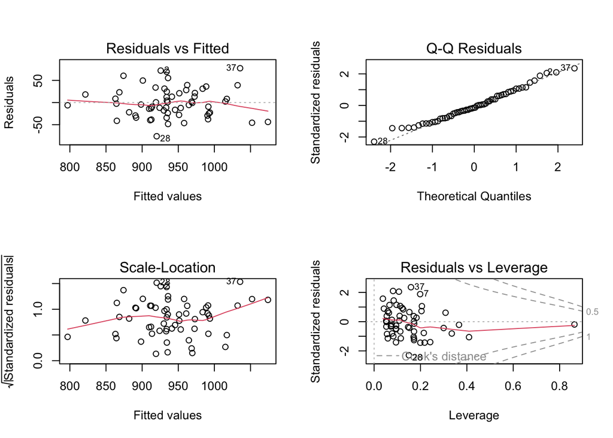

```r
# Primero vamos a ajustar el modelo lineal ordinario con todas las observaciones, es decir, usaremos mcdonald en vez de mcdonald_reducida
modelo_OLS_2 <- lm(MORT ~ PREC + JANT + JULT + OVR65 + POPN + EDUC + NONW + HC,
  data = mcdonald)
# Gráfico de los residuos
par(mfrow=c(2,2))
plot(modelo_OLS_2)
```

```r
# Observamos si hay residuos anormales grandes
rstudent(modelo_OLS_2)
```

```
##           1           2           3           4           5           6
## -0.32535040  2.17292761  0.93392709 -0.27102661  1.15140577 -1.41221677
##           7           8           9          10          11          12
##  1.93219730 -0.99801703  1.14201921 -0.33502617  0.07076757  1.07290741
##          13          14          15          16          17          18
##  0.05647414  0.38138948  0.70584276 -0.66719485  0.02634664  0.26641962
##          19          20          21          22          23          24
## -0.15595968 -0.36589249  0.72100705 -1.14684885 -0.66644020 -1.42999069
##          25          26          27          28          29          30
##  1.06165989 -0.02204225  0.01759516 -2.40182870 -0.19059888  0.83898571
##          31          32          33          34          35          36
## -1.45131207 -1.06139445 -0.47672853 -1.04174819 -0.84187905 -0.80429810
##          37          38          39          40          41          42
##  2.47003625  0.65050490  0.88844939  1.59737269 -0.13593831  0.12278280
##          43          44          45          46          47          48
##  0.37428340  0.24556709 -1.14234724 -1.15706074  0.60696989 -0.80825569
##          49          50          51          52          53          54
## -0.21240704 -0.43091438 -0.27246120  1.46273741  0.60127103 -0.51675158
##          55          56          57          58          59          60
## -0.77031622 -1.26965487  2.12009226 -0.41881103 -1.45587624  0.38856884
```

[output not shown]

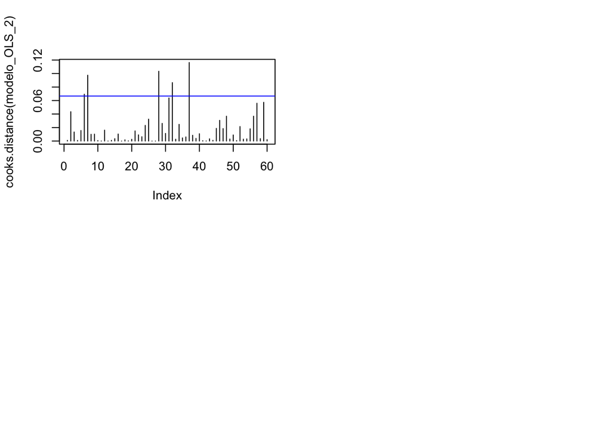

```r
# Observamos los puntps más influyente mendia la distancia de Cook
plot(cooks.distance(modelo_OLS_2), type = "h")
abline(h = 4/nrow(mcdonald), col = "blue")

# Identificamos las observaciones mas influyentes
which(cooks.distance(modelo_OLS_2) > 4/nrow(mcdonald))
```

En este apartado se ha analizado el comportamiento del modelo OLS reducido con todas las observaciones, es decir, con las 60 observaciones de la base de datos mcdonald. Principalmente se ha comprobado se ha realizado un analisis de residuos y se han detectado los puntos más conflictivos, es especial, los más influyentes.

Primero se ha realizado un análisis gráfico de los residuos en el cual se observa un comportamiendo normal en cuanto a linealidad, normalidad y homocedasticidad. Sin embargo, también se han observado puntos bastante influyentes. Despues, se han analizado los residuos estudentizados y se ha observado que algunos valores eran mayor que 2 lo que indica que hay puntos conflictivos, especialmente, las observaciones 28 y 37. Además, se ha calculado la distancia de Cook, la cual nos indica que las observaciones más influyentes son 6, 7, 28, 32, 37.

### b. El objetivo ahora es reestimar el modelo finalmente elegido en el ejercicio 1 mediante regresión robusta empleando los M-estimadores de Huber para reducir la influencia de posibles puntos extremos sin eliminarlos. Para ello se tomarán las 60 observaciones originales.

```r
# Cargamos el paquete MASS para poder emplear los M-estimadores de Huber
library(MASS)
# Realizamos el modelo robusto empleando M-estimadores de Huber
modelo_robusto <- rlm(MORT ~ PREC + JANT + JULT + OVR65 + POPN + EDUC + NONW + HC,
  data = mcdonald)
# Resumen del modelo
summary(modelo_robusto)
```

```
##
## Call: rlm(formula = MORT ~ PREC + JANT + JULT + OVR65 + POPN + EDUC +
##     NONW + HC, data = mcdonald)
## Residuals:
##     Min      1Q  Median      3Q     Max
## -77.384 -22.435  -1.338  22.403  80.135
##
## Coefficients:
##             Value     Std. Error t value
## (Intercept) 2020.0006  363.5898     5.5557
## PREC           1.6205    0.9115     1.7777
## JANT          -2.7247    0.7419    -3.6725
## JULT          -3.1863    1.5219    -2.0936
## OVR65         -8.5337    7.6595    -1.1141
## POPN        -145.0636   65.1672    -2.2260
## EDUC         -29.9952    7.6008    -3.9463
## NONW           5.4661    0.9941     5.4986
## HC             0.0310    0.0806     0.3841
##
## Residual standard error: 33.27 on 51 degrees of freedom
```

### Tras estimarlo, se pide compararlo con el modelo anterior y comprobar si ha habido algún cambio en los coeficientes. ¿Resulta lógico el resultado obtenido?

```r
# Comparamos los coeficientes de ambos modelos para poder compararlos
summary(modelo_OLS_2)
```

```
##
## Call:
## lm(formula = MORT ~ PREC + JANT + JULT + OVR65 + POPN + EDUC +
##     NONW + HC, data = mcdonald)
##
## Residuals:
##     Min      1Q  Median      3Q     Max
## -76.060 -23.972  -3.516  22.030  77.577
##
## Coefficients:
##               Estimate Std. Error t value Pr(>|t|)
## (Intercept) 1935.40996  359.98377   5.376 1.91e-06 ***
## PREC           1.71821    0.90250   1.904 0.062582 .
## JANT          -2.70548    0.73455  -3.683 0.000557 ***
## JULT          -3.14790    1.50686  -2.089 0.041712 *
## OVR65         -7.01556    7.58353  -0.925 0.359268
## POPN        -136.17134   64.52087  -2.111 0.039740 *
## EDUC         -26.87627    7.52537  -3.571 0.000785 ***
## NONW           5.66842    0.98424   5.759 4.88e-07 ***
## HC             0.03118    0.07984   0.390 0.697795
## ---
## Signif. codes:  0 '***' 0.001 '**' 0.01 '*' 0.05 '.' 0.1 ' ' 1
##
## Residual standard error: 35.92 on 51 degrees of freedom
## Multiple R-squared:  0.7118, Adjusted R-squared:  0.6666
## F-statistic: 15.75 on 8 and 51 DF,  p-value: 2.175e-11
```

```r
summary(modelo_robusto)
```

```
##
## Call: rlm(formula = MORT ~ PREC + JANT + JULT + OVR65 + POPN + EDUC +
##     NONW + HC, data = mcdonald)
## Residuals:
##     Min      1Q  Median      3Q     Max
## -77.384 -22.435  -1.338  22.403  80.135
##
## Coefficients:
##             Value     Std. Error t value
## (Intercept) 2020.0006  363.5898     5.5557
## PREC           1.6205    0.9115     1.7777
## JANT          -2.7247    0.7419    -3.6725
## JULT          -3.1863    1.5219    -2.0936
## OVR65         -8.5337    7.6595    -1.1141
## POPN        -145.0636   65.1672    -2.2260
## EDUC         -29.9952    7.6008    -3.9463
## NONW           5.4661    0.9941     5.4986
## HC             0.0310    0.0806     0.3841
##
## Residual standard error: 33.27 on 51 degrees of freedom
```

Al comparar ambos modelos se ha observado que los coeficientes son prácticamente iguales, lo que indica que la relación entre las variables y la mortalidad tiene sentido en ambos modelo. Sin embargo, los coeficientes de las variables EDUC, POPN y OVR65 presentan diferencias algo mayores en comparación al resto. En cuanto a la varible HC, se observa que sigue teniendo un efecto bastante pequeño en ambos modelos.

El resultado es totalmente logico debido a que la regresión robusta disminuye la influencia de las observaciones más influyentes como era el caso de las observaciones 6, 7, 28, 32 y 37, por lo que los coeficientes estan menos condicionados por esos puntos. Ademas, el hecho de que no haya grandes cambios en los coeficientes nos indica que, aunque haya observaciones influyentes, su efecto no es muy grande como para cambiar el modelo o ajustarlo.

### ¿Qué observaciones tienen un peso reducido con este método? Valorar este resultado con el análisis de los residuos del apartado anterior.

El resultado tiene sentido con el análisis de los residuos del apartado anterior ya que la regresión robusta ha reducido la influencia de estas observaciones sin elimanarlas, de manera que los coeficientes estan menos condicionados por algun punto extremo. En consecuencia, obtenemos un modelo robusto menos sensible a puntos muy influyentes.

### c. Realizar una regresión resistente con el método LTS. Comparar el resultado con el apartado anterior.

```r
# Cargamos el paquete necesario
library(robustbase)
# Realizamos una regresion resistente con el modelo LTS
modelo_LTS <- ltsReg(MORT ~ PREC + JANT + JULT + OVR65 + POPN + EDUC + NONW + HC,
  data = mcdonald)
# Resumen de los modelos
summary(modelo_robusto)
```

```
##
## Call: rlm(formula = MORT ~ PREC + JANT + JULT + OVR65 + POPN + EDUC +
##     NONW + HC, data = mcdonald)
## Residuals:
##     Min      1Q  Median      3Q     Max
## -77.384 -22.435  -1.338  22.403  80.135
##
## Coefficients:
##             Value     Std. Error t value
## (Intercept) 2020.0006  363.5898     5.5557
## PREC           1.6205    0.9115     1.7777
## JANT          -2.7247    0.7419    -3.6725
## JULT          -3.1863    1.5219    -2.0936
## OVR65         -8.5337    7.6595    -1.1141
## POPN        -145.0636   65.1672    -2.2260
## EDUC         -29.9952    7.6008    -3.9463
## NONW           5.4661    0.9941     5.4986
## HC             0.0310    0.0806     0.3841
##
## Residual standard error: 33.27 on 51 degrees of freedom
```

```r
summary(modelo_LTS)
```

```
##
## Call:
## ltsReg.formula(formula = MORT ~ PREC + JANT + JULT + OVR65 +
##     POPN + EDUC + NONW + HC, data = mcdonald)
##
## Residuals (from reweighted LS):
##     Min      1Q  Median      3Q     Max
## -80.165 -12.994   0.000   9.231  82.856
##
## Coefficients:
##             Estimate Std. Error t value Pr(>|t|)
## Intercept 2068.43215  388.58316   5.323 2.95e-06 ***
## PREC        -0.01434    1.04936  -0.014  0.98915
## JANT        -2.61870    0.75643  -3.462  0.00117 **
## JULT        -3.09460    1.73657  -1.782  0.08135 .
## OVR65        4.25194    7.89359   0.539  0.59272
## POPN      -156.47052   67.45747  -2.320  0.02486 *
## EDUC       -39.92510    7.70907  -5.179 4.81e-06 ***
## NONW         8.44584    1.18287   7.140 5.62e-09 ***
## HC           0.19890    0.27349   0.727  0.47074
## ---
## Signif. codes:  0 '***' 0.001 '**' 0.01 '*' 0.05 '.' 0.1 ' ' 1
##
## Residual standard error: 35.11 on 46 degrees of freedom
## Multiple R-Squared: 0.7811,  Adjusted R-squared: 0.7431
## F-statistic: 20.52 on 8 and 46 DF,  p-value: 8.547e-13
```

En conclusión, segun el modelo LTS las varaible EDUC, NONW y POPN son las más importantes para explicar la mortalidad y que el efecto de las variables menos estables dependen de puntos extremos o influyentes.

### d. Hallar los intervalos de confianza al 95% de los coeficientes del apartado anterior. ¿Qué coeficientes resultan significativos según su intervalo?

```r
# Para obtener el intervalo de confianza primero extraemos los coeficientes y errores estandar
coeficientes_LTS<-summary(modelo_LTS)$coefficients

# Calculamos los intervarlos de confianza al 95%
interv_LTS <- cbind(LI = coeficientes_LTS[,1] - 1.96 * coeficientes_LTS[,2], LS = coeficientes_LTS[,1] + 1.96 * coeficientes_LTS[,2])
interv_LTS
```

```
##                     LI           LS
## Intercept 1306.8091487 2830.0551484
## PREC        -2.0710874    2.0424025
## JANT        -4.1012927   -1.1360986
## JULT        -6.4982754    0.3090806
## OVR65      -11.2194883   19.7233714
## POPN      -288.6871532  -24.2538821
## EDUC       -55.0348707  -24.8153221
## NONW         6.1274154   10.7642588
## HC          -0.3371299    0.7349336
```

Se han calculado los intervalos de confianza al 95%. Hay que tener en cuenta que un coeficiente es estadisticamente significativo si su intervalo de confianza, definido entre el limite inferior y superior, no contiene 0.

Teniendo en cuenta esta iformación, los coeficientes de las varaibles JANT, POPN, EDUC y NONW son significativos, mietras que PREC, OVR65 y HC no lo son debido a que sus intervalos de confianza sí contienen el 0.

## Ejercicio 3 (10 pt.)

Se sospecha que pueda haber algunas posibles no linealidades estructurales en la relación entre la mortalidad y algunas variables regresoras seleccionadas. Se pide modelizar una de las variables explicativas mediante una regresión a trozos con un punto de cambio (breakpoint) dentro del modelo múltiple propuesto. Aquí también utilizaremos la base de datos completa.

### a. Si se aplica este procedimiento a cada una de las variables del modelo reducido final del ejercicio 1, candidatas según el criterio AIC, podemos implementar un procedimiento automático en R que seleccione las 3 variables más destacadas y señalar la que reduce más el AIC si se modeliza a trozos dentro del modelo múltiple.

```r
# Queremos el modelo reducido final del apartado 1 con todas las observaciones, es decir, modelo_OLS_2
# Hallamos el AIC del modelo que va a ser el valor de referencia
AIC(modelo_OLS_2)
```

```
## [1] 610.2663
```

```r
# Creamos una lista con las variables del modelo reducido
variables <- c("PREC","JANT","JULT","OVR65","POPN","EDUC","NONW","HC")
# Creamos un data frame donde vamos a guardar los resultados
resultados<- data.frame()
# Creamos un bucle para que se repita el mismo procedimiento para cada variable y no tener que hacerlo una por una
for (v in variables){
  # Seleccionamos el breakpoint
  corte<-quantile(mcdonald[[v]],0.5) # Usamos la mediana de la variable v
  # Creamos la variable a trozos la cual vale 0 antes del corte y aumenta de manera lineal despues del corte
  mcdonald$trozo<-pmax(0,mcdonald[[v]]-corte)
  # Calculamos el modelo multiple con la variable a trozos
  modelo_trozo<- lm(MORT ~ PREC + JANT + JULT + OVR65 + POPN + EDUC + NONW + HC + trozo, data = mcdonald)
  # Guardamos el AIC del modelo y el nombre de la variable
  resultados<-rbind(resultados, data.frame(variable=v, AIC=AIC(modelo_trozo)))
}
# Mostramos los resultados
resultados
```

```
##   variable      AIC
## 1     PREC 610.4769
## 2     JANT 612.1802
## 3     JULT 610.2950
## 4    OVR65 612.1534
## 5     POPN 612.0391
## 6     EDUC 610.7757
## 7     NONW 610.5465
## 8       HC 606.0026
```

```r
# Ahora tenemos que calcular la diferencia de AIC respecto al modelo base
resultados$delta_AIC<- AIC(modelo_OLS_2)-resultados$AIC
# Ordenamos de mayor a menor mejora
resultados_ordenados <- resultados[order(-resultados$delta_AIC), ]
# Mostramos los resultados
resultados_ordenados
```

```
##   variable      AIC   delta_AIC
## 8       HC 606.0026  4.26375529
## 3     JULT 610.2950 -0.02872065
## 1     PREC 610.4769 -0.21055570
## 7     NONW 610.5465 -0.28017980
## 6     EDUC 610.7757 -0.50940216
## 5     POPN 612.0391 -1.77273053
## 4    OVR65 612.1534 -1.88704996
## 2     JANT 612.1802 -1.91385925
```

Los resultados muestran que las tres variables más destacadas son HC, JULT y PREC, debido a que muestran el valor de AIC más bajo. La variable que reduce más el AIC es la varaible HC, lo que idica que es la variable con mayor evidencia de no linealidad.

### b. Realizar una regresión de este tipo con la variable regresora que presenta la mayor mejora en el criterio AIC al permitir un punto de cambio. Especificar el modelo que se va estimar con su fórmula explicando qué significan los coeficientes que acompañan a dicha variable. El modelo se debe reestimar mediante regresión robusta para reducir la influencia de la observación extrema detectada en el Ejercicio 1 manteniendo las 60 observaciones originales. Interpretar los resultados obtenidos.

```r
# Calculamos el punto de cambio usando la mediana de HC (variable que presenta mayor mejora en el criterio AIC)
cambio_HC<-median(mcdonald$HC)
cambio_HC
```

```
## [1] 14.5
```

```r
# Calculamos el modelo lineal con HC a trozos, por lo que HC va a tener un efecto distinto antes y depues del corte
modelo_HC <- lm(MORT ~ PREC + JANT + JULT + OVR65 + POPN + EDUC + NONW + HC + pmax(HC - cambio_HC, 0), data = mcdonald)
# Resumen del modelo
summary(modelo_HC)
```

```
##
## Call:
## lm(formula = MORT ~ PREC + JANT + JULT + OVR65 + POPN + EDUC +
##     NONW + HC + pmax(HC - cambio_HC, 0), data = mcdonald)
##
## Residuals:
##    Min     1Q Median     3Q    Max
## -85.61 -20.33  -3.44  18.81  80.08
##
## Coefficients:
##                          Estimate Std. Error t value Pr(>|t|)
## (Intercept)             1715.2148   357.6161   4.796  1.5e-05 ***
## PREC                       2.1225     0.8821   2.406 0.019864 *
## JANT                      -2.5075     0.7092  -3.536 0.000887 ***
## JULT                      -1.4167     1.6221  -0.873 0.386621
## OVR65                     -7.2578     7.2702  -0.998 0.322945
## POPN                    -129.2977    61.9181  -2.088 0.041893 *
## EDUC                     -24.3397     7.2943  -3.337 0.001605 **
## NONW                       4.3365     1.1012   3.938 0.000255 ***
## HC                         3.3857     1.4322   2.364 0.022002 *
## pmax(HC - cambio_HC, 0)   -3.3580     1.4316  -2.346 0.023003 *
## ---
## Signif. codes:  0 '***' 0.001 '**' 0.01 '*' 0.05 '.' 0.1 ' ' 1
##
## Residual standard error: 34.43 on 50 degrees of freedom
## Multiple R-squared:  0.7404, Adjusted R-squared:  0.6937
## F-statistic: 15.84 on 9 and 50 DF,  p-value: 7.563e-12
```

```r
# Calculamos el AIC del modelo para comprobar su mejora
AIC(modelo_HC)
```

```
## [1] 606.0026
```

Como se ha explicado en el apartado anterior, la variable que más reduce el AI al permitir un punto de cambio es HC, por lo que se realiza un modelo de regresión a trozos fijando como breakpoint el valor de la mediana de HC (14,5).

El modelo es: $\text{MORT} = \beta_0 + \beta_1\,\text{PREC} + \cdots + \beta_{\mathrm{HC}}\,\text{HC} + \beta_{\mathrm{HC}+}\,(\text{HC} - 14.5)^{+}$

donde $(\text{HC} - 14.5)^{+} = \max(\text{HC}-14.5,\,0)$

El coeficiente de HC (3.3857) representa la pendiente antes del punto de cambio. Esto significa que para valores de HC≤14,5, un aumento de HC produce un incremento de la mortalidad. En cuanto al coeficiente del término a trozos (-3.3580) indica cuanto cambia la pendiente después del breakpoint, es decir, a partir del punto de cambio. Por lo que, para HC>14.5, el efecto es aproximadamente 3.39-3.36≈0, es decir, que una vez se ha superado el umbral, el efecto de HC prácticamente desaparece.

```r
# Reestimamos el modelo con regresión robusta para reducir la influencia de los valores extremos
modelo_HC_robusto <- rlm(MORT ~ PREC + JANT + JULT + OVR65 + POPN + EDUC + NONW + HC + pmax(HC - cambio_HC, 0), data = mcdonald)
# Resumen del modelo
summary(modelo_HC_robusto)
```

```
##
## Call: rlm(formula = MORT ~ PREC + JANT + JULT + OVR65 + POPN + EDUC +
##     NONW + HC + pmax(HC - cambio_HC, 0), data = mcdonald)
## Residuals:
##     Min      1Q  Median      3Q     Max
## -92.013 -20.623  -2.251  23.843  82.311
##
## Coefficients:
##                         Value     Std. Error t value
## (Intercept)             1661.2507  350.1248     4.7447
## PREC                       2.2264    0.8636     2.5779
## JANT                      -2.4465    0.6943    -3.5235
## JULT                      -1.1078    1.5881    -0.6975
## OVR65                     -7.9805    7.1179    -1.1212
## POPN                    -116.0967   60.6211    -1.9151
## EDUC                     -25.2378    7.1415    -3.5340
## NONW                       3.7828    1.0781     3.5087
## HC                         3.7401    1.4022     2.6674
## pmax(HC - cambio_HC, 0)   -3.6982    1.4016    -2.6386
##
## Residual standard error: 32.71 on 50 degrees of freedom
```

Los resultados confirman que la pendiente inicial de HC es positiva mientras que la del término a trozos es negativa, indicando que el efecto de HC sobre la mortalidad disminuye a partir del punto de corte.

Además, se observa al reestimar el modelo robusto, que los coeficientes se mantienen similares a los del modelo OLS, por lo que la relación de las variables explicativas y la mortalidad es estable y el punto influyente detectado en el ejercicio 1 no condiciona de forma relevante los resultados.

## Ejercicio 4 (30 pt.)

En este ejercicio se aborda el problema de la multicolinealidad mediante métodos de regularización y reducción de la dimensionalidad. Partiremos del conjunto de datos mcdonald sin el valor influyente identificado en el ejercicio 1

### a. Estandarizar todas las variables regresoras (media 0 y desviación típica 1) y particionar el conjunto de datos estandarizado en dos subconjuntos: train (70%) y test (30%).

#### Nota: Utilizar una asignación pseudoaleatoria con la semilla set.seed(123). Repetir esta semilla en cada apartado donde los cálculos requieren una aleatorización.

```r
# Asignamos la semilla
set.seed(123)
# Seleccionamos las variables regresoras (se ha realizado en el ejercicio 1, pero lo volvemos hacer paso a paso para evitar errores)
variables_regresoras<- c("PREC","JANT","JULT","OVR65","POPN","EDUC","HOUS","DENS",
              "NONW","WWDRK","POOR","HC","NOX","SOx","HUMID")
# Estandarizamos las variables regresoras
variables_estandarizadas<- scale(mcdonald_reducida[, variables_regresoras])
# Creamos el conjunto de datos con las variables regresoras estandarizadas
mcdonal_red_estandarizado <- data.frame(MORT=mcdonald_reducida$MORT, variables_estandarizadas)
# Particionamos el conjunto de datos estandarizado en dos subconjuntos
n <- nrow(mcdonal_red_estandarizado)
indice_train <- sample(1:n, size=0.7*n) # Indice del conjunto train
# Conjuntos finales
train<-mcdonal_red_estandarizado[indice_train,]
test<-mcdonal_red_estandarizado[-indice_train,]
```

### b. A partir del conjunto de entrenamiento obtenido en el apartado (a), realizar las siguientes tareas:

#### 1. Ajustar un modelo de Regresión por Componentes Principales (PCR) utilizando las variables regresoras estandarizadas.

```r
# Asignamos la semilla
set.seed(123)
# Cargamos el paquete necesario
library(pls)
# Ajustamos un modelo de PCR con las variables regresoras estandarizadas
modelo_PCR <- pcr(MORT~., data=train, scale=FALSE, validation="CV") # Ponemos scale=FALSE porque las variables ya estan estandarizadas
# Resumen del modelo
summary(modelo_PCR)
```

```
## Data:    X dimension: 41 15
##  Y dimension: 41 1
## Fit method: svdpc
## Number of components considered: 15
##
## VALIDATION: RMSEP
## Cross-validated using 10 random segments.
##        (Intercept)  1 comps  2 comps  3 comps  4 comps  5 comps  6 comps
## CV           58.95    60.32    62.13    46.37    47.84    45.06    41.83
## adjCV        58.95    60.30    62.82    45.90    47.45    44.92    40.81
##        7 comps  8 comps  9 comps  10 comps  11 comps  12 comps  13 comps
## CV       36.86    36.72    36.06     40.69      43.1     46.55     47.32
## adjCV    36.44    36.44    35.98     40.25      42.5     45.51     46.23
##        14 comps  15 comps
## CV        48.91     45.46
## adjCV     47.69     44.35
##
## TRAINING: % variance explained
##       1 comps  2 comps  3 comps  4 comps  5 comps  6 comps  7 comps  8 comps
## X       31.54    49.72    65.30    75.11    83.25    87.90    91.69    94.50
## MORT     5.14    17.43    51.47    51.92    56.13    68.26    69.22    69.65
##       9 comps  10 comps  11 comps  12 comps  13 comps  14 comps  15 comps
## X       96.09     97.60     98.53     99.32     99.72     99.94    100.00
## MORT    71.59     74.63     75.75     77.18     77.54     78.49     80.87
```

#### 2. Seleccionar el número óptimo de componentes mediante validación cruzada sobre el conjunto de entrenamiento.

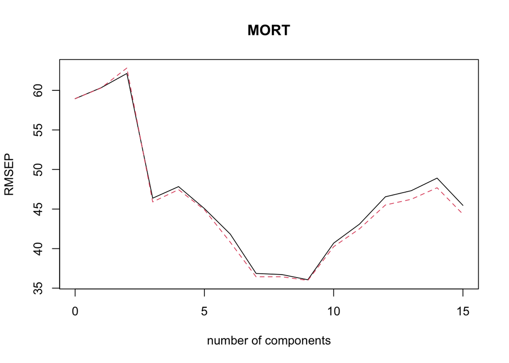

```r
# Asignamos la semilla
set.seed(123)
# Visualizamos el error de validacion cruzada
validationplot(modelo_PCR, val.type = "RMSEP") # El número óptimo de componentes es el que minimiza el RMSEP (Root Mean Squared Error od Prediction)
```

```r
# Extraemos los valores de RMSEP de la validación cruzada
rmsep_val_cruz <- RMSEP(modelo_PCR)$val[1,,]
# Eliminamos el intercepto
rmsep_val_cruz<- rmsep_val_cruz[-1]
# Hallamos el numero optimo de componentes
n_opt_comp<- which.min(rmsep_val_cruz)
n_opt_comp
```

```
## 9 comps
##       9
```

#### 3. Indicar el número de componentes seleccionadas, el error de predicción del modelo en el conjunto test y el porcentaje de varianza de las variables explicativas explicado por las componentes seleccionadas.

```r
# Asignamos la semilla
set.seed(123)
# Una vez sabido que el numero optimo de componentes es 9 calculamos las predicciones del modelo PCR en ej conjunto test
predicciones_test <- predict(modelo_PCR, newdata = test, ncomp = 9)
# Calculamos el error de prediccion del modelo en el conjunto test
error_predicc <- mean((test$MORT-predicciones_test)^2)
error_predicc
```

```
## [1] 3120.286
```

```r
# Calculamos el porcentaje de varianza de las variables explicada por cada componente
varianza_variab <- explvar(modelo_PCR)
porcentaje_varianza <-sum(varianza_variab[1:9])
porcentaje_varianza
```

```
## [1] 96.08681
```

El número de componentes seleccionadas es 9, el error de predicción del modelo en el conjunto test es 3120.286 y el porcentaje de varianza es 96.08681%

#### 4. Explicar si un elevado porcentaje de varianza explicada de las variables regresoras implica necesariamente un mejor comportamiento predictivo.

Un elevado porcentaje de varianza explicada de las variables regresoras no implica necesariamente un mejor comportamiento predictivo, porque los componentes principales se hallan sin considerar la variable de respuesta. Por eso, en PCR el número de componentes se elige mediante la minimización del error de predicción estimado mediante validacion cruzada, y no basandose unicamente en la varianza explicada de la matriz de variables explicativas del modelo de regresión.

### c. A partir del conjunto de entrenamiento obtenido en el apartado (a), realizar las siguientes tareas:

#### 1. Ajustar un modelo de Regresión por Mínimos Cuadrados Parciales (PLS) utilizando las variables regresoras estandarizadas.

```r
# Asignamos la semilla
set.seed(123)
# Ajustamos un modelo de PLS con las variables regresoras estandarizadas
modelo_PLS <- plsr(MORT~., data=train, scale=FALSE, validation="CV") # Ponemos scale=FALSE porque las variables ya estan estandarizadas
# Resumen del modelo
summary(modelo_PLS)
```

```
## Data:    X dimension: 41 15
##  Y dimension: 41 1
## Fit method: kernelpls
## Number of components considered: 15
##
## VALIDATION: RMSEP
## Cross-validated using 10 random segments.
##        (Intercept)  1 comps  2 comps  3 comps  4 comps  5 comps  6 comps
## CV           58.95    44.15    39.39    39.48    40.16    42.64    45.31
## adjCV        58.95    43.30    39.21    38.97    39.70    41.93    44.30
##        7 comps  8 comps  9 comps  10 comps  11 comps  12 comps  13 comps
## CV       47.28    47.79    48.33     47.24     46.11     45.52     46.21
## adjCV    46.15    46.62    47.11     46.10     45.01     44.42     45.05
##        14 comps  15 comps
## CV        45.84     45.46
## adjCV     44.70     44.35
##
## TRAINING: % variance explained
##       1 comps  2 comps  3 comps  4 comps  5 comps  6 comps  7 comps  8 comps
## X       20.37    45.30    54.24    67.58    75.21    79.79    86.96    90.83
## MORT    58.33    66.75    73.61    75.23    76.86    78.02    78.33    78.88
##       9 comps  10 comps  11 comps  12 comps  13 comps  14 comps  15 comps
## X       93.42     95.19     97.06      97.7     98.71     99.53    100.00
## MORT    79.32     79.87     80.23      80.6     80.77     80.84     80.87
```

#### 2. Seleccionar el número óptimo de componentes mediante validación cruzada sobre el conjunto de entrenamiento.

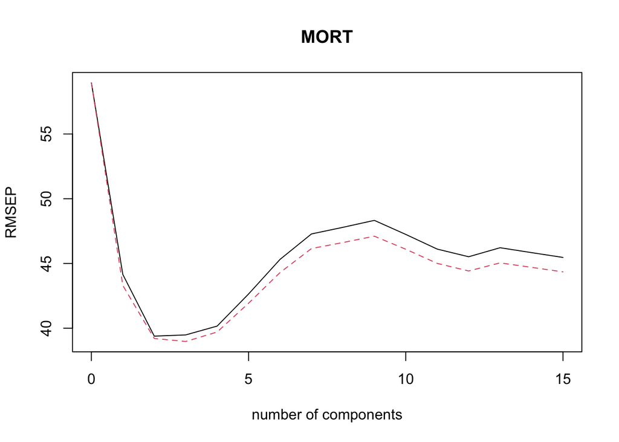

```r
# Asignamos la semilla
set.seed(123)
# Visualizamos el error de validacion cruzada
validationplot(modelo_PLS, val.type = "RMSEP")
```

```r
# Extraemos los valores de RMSEP de la validación cruzada
rmsep_val_cruz_PLS <- RMSEP(modelo_PLS)$val[1,,]
# Eliminamos el intercepto
rmsep_val_cruz_PLS<- rmsep_val_cruz_PLS[-1]
# Hallamos el numero optimo de componentes
n_opt_comp_PLS<- which.min(rmsep_val_cruz_PLS)
n_opt_comp_PLS
```

```
## 2 comps
##       2
```

#### 3. Indicar el número de componentes seleccionados, el error de predicción del modelo en el conjunto test y el porcentaje de varianza de las variables explicativas explicado por las componentes seleccionadas.

```r
# Asignamos la semilla
set.seed(123)
# Una vez sabido que el numero optimo de componentes es 2 calculamos las predicciones del modelo PLS en ej conjunto test
predicciones_test_PLS <- predict(modelo_PLS, newdata = test, ncomp = 2)
# Calculamos el error de prediccion del modelo en el conjunto test
error_predicc_PLS <- mean((test$MORT-predicciones_test_PLS)^2)
error_predicc_PLS
```

```
## [1] 2282.636
```

```r
# Calculamos el porcentaje de varianza de las variables explicada por cada componente
varianza_variab_PLS <- explvar(modelo_PLS)
porcentaje_varianza_PLS <-sum(varianza_variab_PLS[1:2])
porcentaje_varianza_PLS
```

```
## [1] 45.29696
```

El número de componentes seleccionadas es 2, el error de predicción del modelo en el conjunto test es 2282.636 y el porcentaje de varianza es 45.29696%.

#### 4. Comparar los resultados obtenidos con los del modelo PCR y discutir la relación entre varianza explicada de las variables regresoras y capacidad predictiva en ambos métodos.

Se puede observar que aunque el modelo PCR tiene un mayor porcentaje de varianza que el modeo PLS, su capacidad predictiva es peor ya que presenta un mayor error de predicción. Esto ocurre porque en PCR construye los componentes a partir de las variables regresoras estandarizadas sin tener en cuenta la variable MORT (variable respuesta), por lo que puede no dar información que contribuye a la prediccon. En cuanto al PLS los componentes se generan maximizando la relación entre las variales regresoras estandarizas y la variable MORT, lo que permite hallar direcciones asociadas con la respuesta. Por todo ello, el modelo PLS tiene una mejor capacidad predictiva usando menos componentes y con un menor porcentaje de varianza de las variables regresoras estandarizadas.

### d. A partir del conjunto de entrenamiento obtenido en el apartado (a), realizar las siguientes tareas:

#### 1. Ajustar un modelo de regresión Ridge utilizando las variables regresoras estandarizadas.

```r
# Cargamos los paquetes necesarios
library(Matrix)
library(glmnet)
# Asignamos la semilla
set.seed(123)
# Contruimos la matriz de las variables regresoras y el vector respuesta para el conjunto train
matriz_var_reg_train <-as.matrix(train[,-1])
matriz_var_resp_train <- train$MORT
# Ajustmos un modelo de regresion Ridge utilizandos las variables regresoras estandarizadas
modelo_ridge <- glmnet(matriz_var_reg_train, matriz_var_resp_train, alpha = 0)
# Resumen del modelo
summary(modelo_ridge)
```

```
##           Length Class     Mode
## a0         100   -none-    numeric
## beta      1500   dgCMatrix S4
## df         100   -none-    numeric
## dim          2   -none-    numeric
## lambda     100   -none-    numeric
## dev.ratio  100   -none-    numeric
## nulldev      1   -none-    numeric
## npasses      1   -none-    numeric
## jerr         1   -none-    numeric
## offset       1   -none-    logical
## call         4   -none-    call
## nobs         1   -none-    numeric
```

#### 2. Seleccionar el parámetro de regularización mediante validación cruzada, indicando:

##### - λmin, el valor de λ que minimiza el error de validación cruzada,

##### - λ1se, el mayor valor de λ cuyo error de validación cruzada se encuentra a una desviación estándar del mínimo (criterio 1-SE).

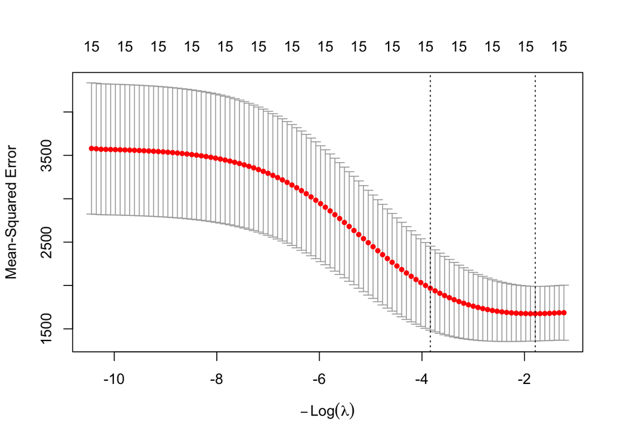

```r
# Asignamos la semilla
set.seed(123)
# Hacemos validacion cruzada para hallar λ
va_cruz_ridge <- cv.glmnet(matriz_var_reg_train, matriz_var_resp_train, alpha = 0)
# Realizamos una gráfica del error de validación cruzada que muentra en el eje x los valores de λ, en el y el error de validación cruzada
plot(va_cruz_ridge)
```

```r
# Hallamos λmin y λ1se
lambda_min <- va_cruz_ridge$lambda.min
lambda_min
```

```
## [1] 5.993433
```

```r
lambda_1se <- va_cruz_ridge$lambda.1se
lambda_1se
```

```
## [1] 46.40497
```

#### 3. Evaluar ambos modelos (λmin y λ1se) en el conjunto test e indicar sus errores de predicción.

```r
# Asignamos la semilla
set.seed(123)
# Construimos la matriz de las variables regresoras y el vector respuesta para el conjunto test
matriz_var_reg_test <-as.matrix(test[,-1])
matriz_var_resp_test <- test$MORT
# Calculamos las predicciones de λmin y λ1se
pred_ridge_min <- predict(va_cruz_ridge, s = lambda_min,newx = matriz_var_reg_test)
pred_ridge_1se <-predict(va_cruz_ridge, s = lambda_1se,newx = matriz_var_reg_test)
# Hallamos los errores de prediccion
error_ridge_min <- mean((matriz_var_resp_test - pred_ridge_min)^2)
error_ridge_min
```

```
## [1] 2460.184
```

```r
error_ridge_1se <- mean((matriz_var_resp_test - pred_ridge_1se)^2)
error_ridge_1se
```

```
## [1] 2672.727
```

#### 4. Comparar los resultados obtenidos con los de los modelos PCR y PLS.

En conclusion, todos los resultados indican que un elevado porcentaje de varianza no garantiza que la capacidad predictiva sea mejor, y que los métodos que incorporan informacion de MORT proporcionan mejores resualtados que los que solo buscan maximizar la variabilidad de las variables explicativas.

#### 5. Explicar brevemente cómo influye el valor de λ en el modelo Ridge.

En el modelo Ridge, el parámetro λ controla cuanto se penalizan los coeficientes del modelo. Cuando λ es pequeño, esta penalizacion es pequeña y da lugar a coeficientes grandes. A medida que λ aumenta, los coeficientes son más pequeños, el modelo es más estable y el problema de multicolinealidad es menor. Sin embargo, si λ es demasiado grande, la predicción puede ser muy mala porque los coeficientes se hacen muy pequeños. Es por ello que el valor de λ se determina mediante validación cruzada.